# Unlocking Voter Preferences: Predicting Political Party Affiliation Through Socio-Demographic Insights

### Author: Oscar Hernandez Mata

### Course: CAP6771 Data Mining

# Packages Installation

```python
pip install pandas
```

```python
pip install tabulate
```

```
Downloading tabulate-0.9.0-py3-none-any.whl (35 kB)
```

```python
pip install pyreadstat
```

[output not shown]

```python
pip install lightgbm
```

[output not shown]

```python
pip install tensorflow
```

```python
pip install xgboost
```

[output not shown]

[output cut: 261 more lines]

[output not shown]

# Introduction

In this project, I utilized two datasets from the General Social Survey (GSS), a nationally representative survey of adults in the United States. Since 1972, the GSS has gathered data on contemporary American society to monitor and explain trends in opinions, attitudes, and behaviors. The datasets contain demographic information such as age, sex, marrital status, ideology, religion, income, social class, political party preferenc, etc. The datasets can be found in the following website [https://gss.norc.org/].

## Data Collection

The first dataset, GSSIdeology, was provided by Professor Brian Crisher from the Department of Government at the University of West Florida and was downloaded from the General Social Survey website. The second dataset, GSS_2022, was also downloaded from the same website. Both datasets were obtained in Stata file format.

## Project Inspiration

This project is inspired by the work of Besjon Tanuzi and Justin Franklin, who posed the question, "How do socio-demographic factors determine the political party affiliation of Americans?" (Tanuzi & Franklin, 2022). In their paper, the authors examine the socio-demographic factors influencing American political party affiliation, with the aim of assisting political parties, policymakers, and interest groups in effectively targeting voters and informing policy decisions [https://papers.ssrn.com/sol3/papers.cfm?abstract_id=4693183]. Consequently, the goal of this project is to create a model that can predict Americans' party affiliations based on socio-demographic characteristics.

### GSSIdeology Dataset

```python
import pandas as pd

# Specify the path to your .dta file
file_path = r'C:\Users\13055\Downloads\Stata practice\Data sets\GSSIdeology.dta'

# Read the .dta file into a pandas DataFrame
dfdta = pd.read_stata(file_path)

# Step 2: Save the DataFrame as a .csv file
output_path =  r'C:\Users\13055\Downloads\Stata practice\Data sets\GSSIdeology.csv'
dfdta.to_csv(output_path, index=False)

csv_file_path = r'C:\Users\13055\Downloads\Stata practice\Data sets\GSSIdeology.csv'

# Read the .csv file into a pandas DataFrame
df = pd.read_csv(csv_file_path)
```

### Data exploration

```python
# Display the number of rows and columns in the DataFrame
num_rows, num_columns = df.shape
print(f"The dataset has {num_rows} rows and {num_columns} columns.")
```

```
The dataset has 1764 rows and 106 columns.
```

### Selecting the relevant variables

The original dataset had 106 variables. By following the research of Tanuzi and Franklin, I selected 16 features that influence Americans' party affiliation:

- polviews: Political views, typically measured on a scale from extremely liberal to extremely conservative.
- age: The age of the respondent.
- income98: Income of the respondent, adjusted to 1998 dollars to account for inflation.
- sex: The gender of the respondent.
- south: Whether the respondent resides in the southern United States.
- divorce: Marital status, specifically whether the respondent has ever been divorced.
- reliten: Religious intensity, indicating how religious the respondent is or how often they attend religious services.
- cappun: Opinions on capital punishment, indicating whether the respondent supports or opposes the death penalty.
- class: Social class, self-identified by the respondent (e.g., working class, middle class).
- grass: Attitudes towards the legalization of marijuana.
- abany: Attitudes towards abortion, specifically if the respondent believes abortion should be legal under any circumstances.
- childs: The number of children the respondent has.
- denom: Religious denomination, indicating the specific religious group or affiliation of the respondent.
- gunlaw: Opinions on gun control laws, indicating whether the respondent supports stricter gun control.
- homosex: Attitudes towards homosexuality, such as whether the respondent believes homosexual relations are wrong.
- partyid: Political party identification, indicating the political party with which the respondent identifies.

```python
selected_columns = [
    'polviews', 'age', 'income98', 'sex', 'south', 'divorce', 'reliten',
    'cappun', 'class', 'grass', 'abany', 'childs', 'denom', 'gunlaw', 'homosex', 'partyid'
]

# Filter the DataFrame to only include selected columns
filtered_df = df[selected_columns]

#Print the first five rows of each selected columns
print(filtered_df.head())
```

```
               polviews  age          income98     sex  south divorce  \
0      slightly liberal   44   $110000 or over    male    1.0      no
1  extrmly conservative   47  $90000 - $109999    male    1.0      no
2      slightly liberal   53  $90000 - $109999  female    1.0     yes
3          conservative   52   $110000 or over    male    1.0      no
4              moderate   52   $50000 to 59999    male    1.0      no

       reliten  cappun          class      grass abany childs  \
0       strong  oppose   middle class      legal   NaN      1
1       strong   favor    upper class  not legal   NaN      3
2       strong  oppose   middle class  not legal   NaN      1
3  no religion   favor   middle class      legal   yes      1
4       strong   favor  working class        NaN    no      1

              denom gunlaw           homosex              partyid
0             other    NaN               NaN  not strong democrat
1  southern baptist    NaN               NaN    strong republican
2             other    NaN               NaN  not strong democrat
3               NaN  favor  not wrong at all  ind,near republican
4  southern baptist  favor      always wrong      strong democrat
```

### Classifying Variables: Categorical, Continuous, and Binary

```python
df_selected = df[selected_columns]

# Function to classify variables
def classify_variables(df):
    categorical = []
    continuous = []
    binary = []

    for col in df.columns:
        unique_values = df[col].dropna().unique()
        if df[col].dtype == 'object' or len(unique_values) < 10:
            if len(unique_values) == 2:
                binary.append(col)
            else:
                categorical.append(col)
        else:
            continuous.append(col)

    return categorical, continuous, binary

# Classify the variables
categorical, continuous, binary = classify_variables(df_selected)

# Display the results
print("Categorical Variables:", categorical)
print("Continuous Variables:", continuous)
print("Binary Variables:", binary)
```

```
Categorical Variables: ['polviews', 'income98', 'reliten', 'class', 'childs', 'denom', 'homosex', 'partyid']
Continuous Variables: ['age']
Binary Variables: ['sex', 'south', 'divorce', 'cappun', 'grass', 'abany', 'gunlaw']
```

### Categories for each categorical variable

```python
# List of categorical variables
categorical_variables = ['polviews', 'income98', 'reliten', 'class', 'childs', 'denom', 'homosex', 'partyid']

# Display unique categories for each categorical variable
for var in categorical_variables:
    print(f"Categories for {var}:")
    print(df[var].unique())
    print("\n")
```

```
Categories for polviews:
['slightly liberal' 'extrmly conservative' 'conservative' 'moderate'
 'slghtly conservative' 'liberal' 'extremely liberal']


Categories for income98:
['$110000 or over' '$90000 - $109999' '$50000 to 59999' '$12500 to 14999'
 '$22500 to 24999' '$35000 to 39999' '$1 000 to 2 999' '$40000 to 49999'
 '$75000 to $89999' '$25000 to 29999' '$60000 to 74999' '$10000 to 12499'
 '$5 000 to 5 999' '$15000 to 17499' '$30000 to 34999' '$4 000 to 4 999'
 '$17500 to 19999' '$6 000 to 6 999' '$20000 to 22499' '$8 000 to 9 999'
 '$7 000 to 7 999' 'under $1 000' '$3 000 to 3 999']


Categories for reliten:
['strong' 'no religion' 'somewhat strong' 'not very strong']


Categories for class:
['middle class' 'upper class' 'working class' 'lower class']


Categories for childs:
['1' '3' '0' '4' '2' '5' 'eight or more' '6' '7']


Categories for denom:
['other' 'southern baptist' nan 'united methodist' 'baptist-dk which'
 'other lutheran' 'other methodist' 'presbyterian c in us' 'episcopal'
 'nat bapt conv of am' 'lutheran-mo synod' 'am baptist asso'
 'luth ch in america' 'no denomination' 'methodist-dk which' 'am lutheran'
 'evangelical luth' 'other baptists' 'wi evan luth synod'
 'lutheran-dk which' 'other presbyterian' 'united pres ch in us'
 'afr meth episcopal' 'presbyterian, merged' 'presbyterian-dk wh'
 'am bapt ch in usa' 'nat bapt conv usa' 'afr meth ep zion']


Categories for homosex:
[nan 'not wrong at all' 'always wrong' 'sometimes wrong'
 'almost always wrong']


Categories for partyid:
['not strong democrat' 'strong republican' 'ind,near republican'
 'strong democrat' 'independent' 'ind,near democrat'
 'not strong republican' 'other party' nan]
```

### Bar chart and number of samples for each category in partyid

```
Number of samples for each category in the 'partyid' column:
partyid
not strong republican    339
not strong democrat      321
independent              263
strong democrat          241
strong republican        225
ind,near democrat        173
ind,near republican      170
other party               29
Name: count, dtype: int64
```

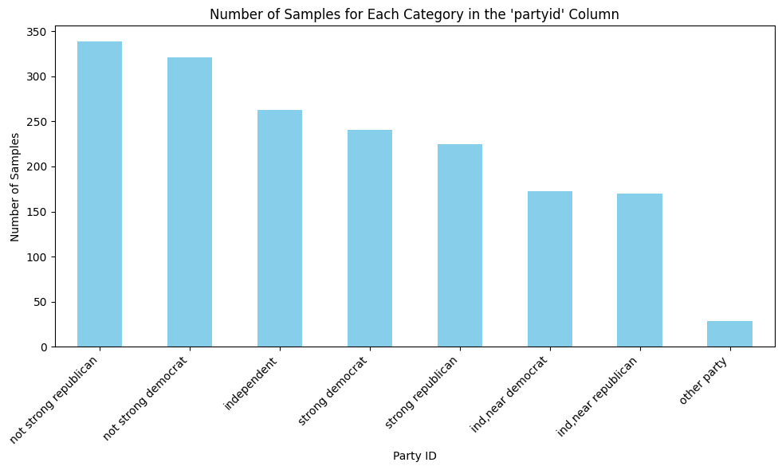

```python
partyid_counts = filtered_df['partyid'].value_counts()

print("Number of samples for each category in the 'partyid' column:")
print(partyid_counts)

# Create a bar chart
plt.figure(figsize=(10, 6))
partyid_counts.plot(kind='bar', color='skyblue')
plt.title("Number of Samples for Each Category in the 'partyid' Column")
plt.xlabel("Party ID")
plt.ylabel("Number of Samples")
plt.xticks(rotation=45, ha='right')  # Rotate x-axis labels and align to the right
plt.tight_layout()  # Adjust layout to make room for the rotated labels
plt.show()
```

### Filter out 'other party'

```python
# Filter out the rows where 'partyid' is 'other party'
filtered_df_no_other = filtered_df[filtered_df['partyid'] != 'other party']

# Verify the changes
partyid_counts_no_other = filtered_df_no_other['partyid'].value_counts()

print("Number of samples for each category in the 'partyid' column after removing 'other party':")
print(partyid_counts_no_other)
```

```
Number of samples for each category in the 'partyid' column after removing 'other party':
partyid
not strong republican    339
not strong democrat      321
independent              263
strong democrat          241
strong republican        225
ind,near democrat        173
ind,near republican      170
Name: count, dtype: int64
```

### Binary variables categories

```python
# Define the list of binary variables
binary_variables = ['sex', 'south', 'divorce', 'cappun', 'grass', 'abany', 'gunlaw']

# Print unique categories for each binary variable
for var in binary_variables:
    unique_values = filtered_df[var].unique()
    print(f"Unique categories for {var}: {unique_values}")
```

```
Unique categories for sex: ['male' 'female']
Unique categories for south: [1. 0.]
Unique categories for divorce: ['no' 'yes']
Unique categories for cappun: ['oppose' 'favor' nan]
Unique categories for grass: ['legal' 'not legal' nan]
Unique categories for abany: [nan 'yes' 'no']
Unique categories for gunlaw: [nan 'favor' 'oppose']
```

### Combining categories

These variables have categories that can be combined, thereby reducing the number of classifications and potentially improving the efficiency of the model. For instance, for polviews, similar political views such as "slightly liberal," "extremely liberal," and "liberal" were combined into a single "liberal" category, while conservative views were similarly grouped. Income98 was categorized into broader income groups like "low income," "lower middle income," "upper middle income," and "high income" to simplify the range of income levels. The childs variable grouped all respondents with two or more children into one category, reducing the complexity of the data. The denom variable consolidated various Protestant denominations and others into broader categories like "Baptist," "Methodist," and "Lutheran," among others, while distinguishing "No Denomination." Lastly, the partyid variable combined responses into three main categories: "Democrat," "Republican," and "Independent," merging near and not strong affiliations with their respective strong categories. This consolidation helps streamline the analysis and improves the clarity and performance of the predictive model.

```python
polviews_combined_mapping = {
    'slightly liberal': 'liberal',
    'extremely liberal': 'liberal',
    'liberal': 'liberal',
    'slghtly conservative': 'conservative',
    'extrmly conservative': 'conservative',
    'conservative': 'conservative',
    'moderate': 'moderate'
}


income98_combined_mapping = {
    'under $1 000': 'low income',
    '$1 000 to 2 999': 'low income',
    '$3 000 to 3 999': 'low income',
    '$4 000 to 4 999': 'low income',
    '$5 000 to 5 999': 'low income',
    '$6 000 to 6 999': 'low income',
    '$7 000 to 7 999': 'low income',
    '$8 000 to 9 999': 'low income',
    '$10000 to 12499': 'low income',
    '$12500 to 14999': 'low income',
    '$15000 to 17499': 'low income',
    '$17500 to 19999': 'low income',
    '$20000 to 22499': 'low income',
    '$22500 to 24999': 'low income',
    '$25000 to 29999': 'lower middle income',
    '$30000 to 34999': 'lower middle income',
    '$35000 to 39999': 'lower middle income',
    '$40000 to 49999': 'lower middle income',
    '$50000 to 59999': 'upper middle income',
    '$60000 to 74999': 'upper middle income',
    '$75000 to $89999': 'high income',
    '$90000 - $109999': 'high income',
    '$110000 or over': 'high income'
}

childs_combined_mapping = {
    '0': '0 children',
    '1': '1 child',
    '2': '2 and more children',
    '3': '2 and more children',
    '4': '2 and more children',
    '5': '2 and more children',
    '6': '2 and more children',
    '7': '2 and more children',
    'eight or more': '2 and more children'
}

denom_combined_mapping = {
    'other': 'Other',
    'southern baptist': 'Baptist',
    'united methodist': 'Methodist',
    'baptist-dk which': 'Baptist',
    'other lutheran': 'Lutheran',
    'other methodist': 'Methodist',
    'presbyterian c in us': 'Presbyterian',
    'episcopal': 'Other Protestant',
    'nat bapt conv of am': 'Baptist',
    'lutheran-mo synod': 'Lutheran',
    'am baptist asso': 'Baptist',
    'luth ch in america': 'Lutheran',
    'no denomination': 'No Denomination',
    'methodist-dk which': 'Methodist',
    'am lutheran': 'Lutheran',
    'evangelical luth': 'Lutheran',
    'other baptists': 'Baptist',
    'wi evan luth synod': 'Lutheran',
    'lutheran-dk which': 'Lutheran',
    'other presbyterian': 'Presbyterian',
    'united pres ch in us': 'Presbyterian',
    'afr meth episcopal': 'Methodist',
    'presbyterian, merged': 'Presbyterian',
    'presbyterian-dk wh': 'Presbyterian',
    'am bapt ch in usa': 'Baptist',
    'nat bapt conv usa': 'Baptist',
    'afr meth ep zion': 'Methodist'
}

partyid_combined_mapping = {
    'strong democrat': 'Democrat',
    'not strong democrat': 'Democrat',
    'ind,near democrat': 'Democrat',
    'strong republican': 'Republican',
    'not strong republican': 'Republican',
    'ind,near republican': 'Republican',
    'independent': 'Independent'
}


# Apply the mapping to the polviews column in filtered_df
filtered_df['polviews_combined'] = filtered_df['polviews'].map(polviews_combined_mapping)

# Apply the mapping to the income98 column in filtered_df
filtered_df['income98_combined'] = filtered_df['income98'].map(income98_combined_mapping)

# Apply the mapping to the childs column in filtered_df
filtered_df['childs_combined'] = filtered_df['childs'].map(childs_combined_mapping)

# Apply the mapping to the denom column in filtered_df
filtered_df['denom_combined'] = filtered_df['denom'].map(denom_combined_mapping)

# Apply the mapping to the partyid column in filtered_df
filtered_df['partyid_combined'] = filtered_df['partyid'].map(partyid_combined_mapping)
```

### Binary mappings for each variable

In this section of the code, binary mappings are defined for various categorical variables to facilitate their use in a predictive model. The sex variable is mapped to 0 for 'male' and 1 for 'female'. The south variable is mapped to 1 if the respondent resides in the southern United States and 0 otherwise. The divorce variable is mapped to 0 for 'no' and 1 for 'yes'. The cappun variable is mapped to 0 for those who oppose capital punishment and 1 for those who favor it. The grass variable is mapped to 1 for respondents who believe marijuana should be legal and 0 for those who believe it should not be legal. The abany variable is mapped to 1 for those who support legal abortion under any circumstances and 0 for those who do not. Lastly, the gunlaw variable is mapped to 1 for those who favor stricter gun control laws and 0 for those who oppose them. These mappings convert categorical data into binary numerical values, simplifying the integration of these variables into machine learning models.

```python
# Define the binary mappings for each variable
sex_mapping = {
    'male': 0,
    'female': 1
}

south_mapping = {
    1.0: 1,
    0.0: 0
}

divorce_mapping = {
    'no': 0,
    'yes': 1
}

cappun_mapping = {
    'oppose': 0,
    'favor': 1
}

grass_mapping = {
    'legal': 1,
    'not legal': 0
}

abany_mapping = {
    'yes': 1,
    'no': 0
}

gunlaw_mapping = {
    'favor': 1,
    'oppose': 0
}

# Apply the mappings to the corresponding columns in filtered_df
filtered_df['sex_binary'] = filtered_df['sex'].map(sex_mapping)
filtered_df['south_binary'] = filtered_df['south'].map(south_mapping)
filtered_df['divorce_binary'] = filtered_df['divorce'].map(divorce_mapping)
filtered_df['cappun_binary'] = filtered_df['cappun'].map(cappun_mapping)
filtered_df['grass_binary'] = filtered_df['grass'].map(grass_mapping)
filtered_df['abany_binary'] = filtered_df['abany'].map(abany_mapping)
filtered_df['gunlaw_binary'] = filtered_df['gunlaw'].map(gunlaw_mapping)
```

[output not shown]

### New dataset

In these line of codes a new dataset is being created for analysis by selecting specific columns that have been processed and mapped appropriately. The list columns_for_analysis includes both the original and transformed variables.

```python
columns_for_analysis = [
    'age', 'polviews_combined', 'income98_combined', 'reliten',
    'denom_combined', 'partyid_combined', 'childs_combined',
    'sex_binary', 'south_binary', 'divorce_binary', 'cappun_binary',
    'grass_binary', 'abany_binary', 'gunlaw_binary', 'class', 'homosex'
]

# Create the new dataset
analysis_df = filtered_df[columns_for_analysis]

# Display the new dataset
print("New dataset for further analysis:")
print(analysis_df.head())

# Display the number of rows and columns in the dataset
print("Number of rows and columns in the dataset:")
print(analysis_df.shape)
```

```
New dataset for further analysis:
   age polviews_combined    income98_combined      reliten denom_combined  \
0   44           liberal          high income       strong          Other
1   47      conservative          high income       strong        Baptist
2   53           liberal          high income       strong          Other
3   52      conservative          high income  no religion            NaN
4   52          moderate  upper middle income       strong        Baptist

  partyid_combined      childs_combined  sex_binary  south_binary  \
0         Democrat              1 child           0             1
1       Republican  2 and more children           0             1
2         Democrat              1 child           1             1
3       Republican              1 child           0             1
4         Democrat              1 child           0             1

   divorce_binary  cappun_binary  grass_binary  abany_binary  gunlaw_binary  \
0               0            0.0           1.0           NaN            NaN
1               0            1.0           0.0           NaN            NaN
2               1            0.0           0.0           NaN            NaN
3               0            1.0           1.0           1.0            1.0
4               0            1.0           NaN           0.0            1.0

           class           homosex
0   middle class               NaN
1    upper class               NaN
2   middle class               NaN
3   middle class  not wrong at all
4  working class      always wrong
Number of rows and columns in the dataset:
(1764, 16)
```

### Checking for missing values

```python
# Check for missing values in the new dataset
missing_values = analysis_df.isnull().sum()

# Print the count of missing values for each column
print("Missing values in each column:")
print(missing_values)
```

```
Missing values in each column:
age                    0
polviews_combined      0
income98_combined      0
reliten                0
denom_combined       776
                    ...
grass_binary         628
abany_binary         624
gunlaw_binary        602
class                  0
homosex              653
Length: 16, dtype: int64
```

### Handling missing values for categorical and numerical variables

To handle the missing values, I decided to treat them as a separate category. Removing them from the dataset would have resulted in a significant loss of information.

```python
# Handle missing values by treating them as a separate category for categorical variables
for col in ['polviews_combined', 'reliten', 'denom_combined', 'partyid_combined', 'class', 'homosex']:
    analysis_df[col].fillna('Missing', inplace=True)

# For numerical columns, create a missing indicator and fill missing values with a placeholder (e.g., mean)
for col in ['age', 'sex_binary', 'south_binary', 'divorce_binary', 'cappun_binary', 'grass_binary', 'abany_binary', 'gunlaw_binary']:
    analysis_df[col + '_missing'] = analysis_df[col].isnull().astype(int)
    analysis_df[col].fillna(analysis_df[col].mean(), inplace=True)

# Check the number of rows and columns in the cleaned dataset
print("Number of rows and columns in the cleaned dataset:")
print(analysis_df.shape)

# Verify that there are no missing values left
print("Missing values after handling:")
print(analysis_df.isnull().sum())
```

```
Number of rows and columns in the cleaned dataset:
(1764, 24)
Missing values after handling:
age                       0
polviews_combined         0
income98_combined         0
reliten                   0
denom_combined            0
                         ..
divorce_binary_missing    0
cappun_binary_missing     0
grass_binary_missing      0
abany_binary_missing      0
gunlaw_binary_missing     0
Length: 24, dtype: int64
```

[output not shown]

[output cut: 101 more lines]

[output not shown]

### Final dataset for the model

```python
# Select only the desired columns for the final analysis
columns_for_analysis = [
    'age', 'polviews_combined', 'income98_combined', 'reliten',
    'denom_combined', 'partyid_combined', 'childs_combined',
    'sex_binary', 'south_binary', 'divorce_binary', 'cappun_binary',
    'grass_binary', 'abany_binary', 'gunlaw_binary', 'class', 'homosex'
]

# Create the final dataset
final_analysis_df = analysis_df[columns_for_analysis]

# Check the number of rows and columns in the final dataset
print("Number of rows and columns in the final dataset:")
print(final_analysis_df.shape)

# Verify that there are no missing values left
print("Missing values after handling:")
print(final_analysis_df.isnull().sum())
```

```
Number of rows and columns in the final dataset:
(1764, 16)
Missing values after handling:
age                  0
polviews_combined    0
income98_combined    0
reliten              0
denom_combined       0
                    ..
grass_binary         0
abany_binary         0
gunlaw_binary        0
class                0
homosex              0
Length: 16, dtype: int64
```

### Label Encoding

Label encoding is applied to several categorical variables to transform them into numerical format, which is necessary for the model. The list label_cols contains the names of the columns that need to be encoded: polviews_combined, income98_combined, reliten, denom_combined, childs_combined, class, and homosex. A dictionary label_encoders is created to store the label encoders and their corresponding mappings for each column. The dataframe encoded_df is a copy of final_analysis_df to preserve the original data. For each column in label_cols, a LabelEncoder is instantiated, and the column is transformed using the fit_transform method, creating a new column with the suffix '_encoded' that contains the numerical labels.

```python
from sklearn.model_selection import train_test_split
from sklearn.ensemble import RandomForestClassifier
from sklearn.metrics import accuracy_score, classification_report, confusion_matrix
from sklearn.preprocessing import LabelEncoder

# Label Encoding
label_cols = [
    'polviews_combined', 'income98_combined', 'reliten', 'denom_combined',
    'childs_combined', 'class', 'homosex'
]

# Create a dictionary to store the label encoders and their corresponding mappings
label_encoders = {}
encoded_df = final_analysis_df.copy()

for col in label_cols:
    le = LabelEncoder()
    encoded_df[col + '_encoded'] = le.fit_transform(final_analysis_df[col])
    label_encoders[col] = le

# Verify the transformation
print("Transformed final_analysis_df with encoded columns:")
print(encoded_df.head())

# Optionally, save the original and encoded mappings for reference
for col in label_cols:
    mapping = dict(zip(label_encoders[col].classes_, label_encoders[col].transform(label_encoders[col].classes_)))
    print(f"Mapping for {col}: {mapping}")
```

```
Transformed final_analysis_df with encoded columns:
   age polviews_combined    income98_combined      reliten denom_combined  \
0   44           liberal          high income       strong          Other
1   47      conservative          high income       strong        Baptist
2   53           liberal          high income       strong          Other
3   52      conservative          high income  no religion        Missing
4   52          moderate  upper middle income       strong        Baptist

  partyid_combined      childs_combined  sex_binary  south_binary  \
0         Democrat              1 child           0             1
1       Republican  2 and more children           0             1
2         Democrat              1 child           1             1
3       Republican              1 child           0             1
4         Democrat              1 child           0             1

   divorce_binary  cappun_binary  grass_binary  abany_binary  gunlaw_binary  \
0               0            0.0      1.000000      0.383333        0.80895
1               0            1.0      0.000000      0.383333        0.80895
2               1            0.0      0.000000      0.383333        0.80895
3               0            1.0      1.000000      1.000000        1.00000
4               0            1.0      0.279049      0.000000        1.00000

           class           homosex  polviews_combined_encoded  \
0   middle class           Missing                          1
1    upper class           Missing                          0
2   middle class           Missing                          1
3   middle class  not wrong at all                          0
4  working class      always wrong                          2

   income98_combined_encoded  reliten_encoded  denom_combined_encoded  \
0                          0                3                       5
1                          0                3                       0
2                          0                3                       5
3                          0                0                       3
4                          3                3                       0

   childs_combined_encoded  class_encoded  homosex_encoded
0                        1              1                0
1                        2              2                0
2                        1              1                0
3                        1              1                3
4                        1              3                2
Mapping for polviews_combined: {'conservative': 0, 'liberal': 1, 'moderate': 2}
Mapping for income98_combined: {'high income': 0, 'low income': 1, 'lower middle income': 2, 'upper middle income': 3}
Mapping for reliten: {'no religion': 0, 'not very strong': 1, 'somewhat strong': 2, 'strong': 3}
Mapping for denom_combined: {'Baptist': 0, 'Lutheran': 1, 'Methodist': 2, 'Missing': 3, 'No Denomination': 4, 'Other': 5, 'Other Protestant': 6, 'Presbyterian': 7}
Mapping for childs_combined: {'0 children': 0, '1 child': 1, '2 and more children': 2}
Mapping for class: {'lower class': 0, 'middle class': 1, 'upper class': 2, 'working class': 3}
Mapping for homosex: {'Missing': 0, 'almost always wrong': 1, 'always wrong': 2, 'not wrong at all': 3, 'sometimes wrong': 4}
```

### Random Forest Classifier

A Random Forest classifier is created to predict a target variable called partyid_combined. First, it selects the features (independent variables) by dropping the target variable and any label columns from a DataFrame named encoded_df. The target variable (partyid_combined) is then separated out. The data is split into training and testing sets using an 80-20 split. A Random Forest classifier is initialized with a fixed random state for reproducibility, and then trained using the training data.

```
Accuracy of the random forest model: 0.55

Classification Report:
              precision    recall  f1-score   support

    Democrat       0.53      0.70      0.60       141
 Independent       0.47      0.13      0.21        60
     Missing       0.00      0.00      0.00         6
  Republican       0.59      0.60      0.60       146

    accuracy                           0.55       353
   macro avg       0.40      0.36      0.35       353
weighted avg       0.54      0.55      0.52       353


Confusion Matrix:
[[99  5  0 37]
 [30  8  0 22]
 [ 4  0  0  2]
 [54  4  0 88]]
```

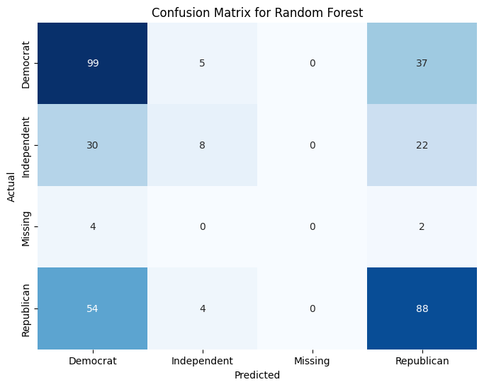

```python
# Select features and target
X = encoded_df.drop(['partyid_combined'] + label_cols, axis=1)
y = encoded_df['partyid_combined']

# Split the data into training and testing sets
X_train, X_test, y_train, y_test = train_test_split(X, y, test_size=0.2, random_state=42)

# Train a random forest classifier
clf = RandomForestClassifier(random_state=42)
clf.fit(X_train, y_train)

# Make predictions
y_pred = clf.predict(X_test)

# Evaluate the model
accuracy = accuracy_score(y_test, y_pred)
print(f"Accuracy of the random forest model: {accuracy:.2f}")

# Detailed evaluation
print("\nClassification Report:")
print(classification_report(y_test, y_pred, zero_division=0))

print("\nConfusion Matrix:")
print(confusion_matrix(y_test, y_pred))

# Confusion Matrix
cm = confusion_matrix(y_test, y_pred)

# Define the category names
categories = le_target.classes_

# Create a DataFrame for the confusion matrix
cm_df = pd.DataFrame(cm, index=categories, columns=categories)

# Plot the confusion matrix
plt.figure(figsize=(8, 6))
sns.heatmap(cm_df, annot=True, fmt='d', cmap='Blues', cbar=False)
plt.title("Confusion Matrix for Random Forest")
plt.xlabel("Predicted")
plt.ylabel("Actual")
plt.show()
```

### Results of the Random Forest

The results of the random forest model's performance indicate that 55% of the predictions are correct. The classification report provides detailed metrics for each class. For Democrats, the model correctly identifies Democrats 53% of the time out of all predicted Democrats. It successfully finds 70% of all actual Democrats in the test data. The F1-score, which balances both precision and recall, is 0.60, indicating a decent performance. There are 141 Democrats in the test data.

For Independents, the model correctly identifies Independents 47% of the time out of all predicted Independents. However, it only correctly identifies 13% of all actual Independents in the test data. The F1-score is low at 0.21, indicating poor performance. There are 60 Independents in the test data.

For the Missing category, the model fails completely, with 0% precision, recall, and F1-score, meaning it couldn't correctly identify any of the 6 actual instances.

For Republicans, the model correctly identifies Republicans 59% of the time out of all predicted Republicans. It successfully finds 60% of all actual Republicans in the test data. The F1-score is 0.60, showing a fair performance. There are 146 Republicans in the test data.

In conclusion, the model is fairly good at predicting Democrats and Republicans but struggles significantly with Independents and completely fails with the Missing category.

The confusion matrix reveals how well the model is predicting each class. For Democrats, the model correctly identifies 99 of them but incorrectly classifies 5 as Independents and 37 as Republicans. For Independents, the model correctly identifies only 8, while misclassifying 30 as Democrats and 22 as Republicans. The model fails to correctly identify any of the Missing category instances, misclassifying 4 as Democrats and 2 as Republicans. For Republicans, the model correctly identifies 88, but incorrectly classifies 54 as Democrats and 4 as Independents.

### AdaBoost Classifier

This code trains an AdaBoost model to predict political party affiliation, aiming to improve prediction accuracy compared to the previously used random forest model, which accuracy was only of 55%. AdaBoost, which stands for Adaptive Boosting, combines multiple weak classifiers (in this case, simple decision trees) to create a stronger overall model.

```
Accuracy of the AdaBoost model: 0.54

Classification Report for AdaBoost:
              precision    recall  f1-score   support

    Democrat       0.53      0.60      0.56       141
 Independent       0.41      0.18      0.25        60
     Missing       0.00      0.00      0.00         6
  Republican       0.60      0.66      0.63       146

    accuracy                           0.54       353
   macro avg       0.38      0.36      0.36       353
weighted avg       0.53      0.54      0.53       353


Confusion Matrix for AdaBoost:
[[84 12  5 40]
 [26 11  2 21]
 [ 4  0  0  2]
 [45  4  1 96]]
```

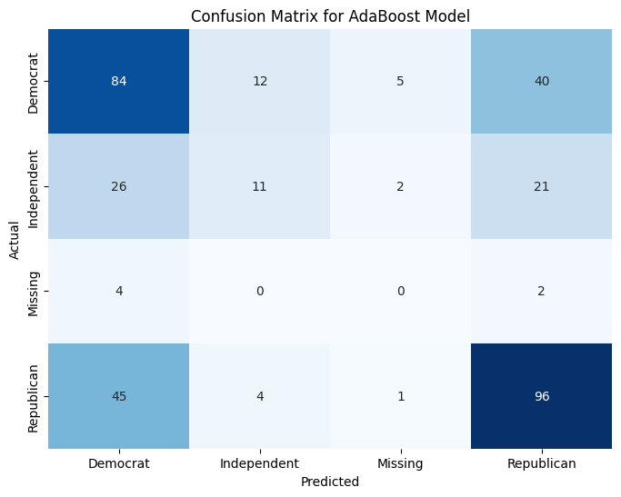

```python
from sklearn.ensemble import AdaBoostClassifier
from sklearn.tree import DecisionTreeClassifier
import seaborn as sns

# Select features and target
X = encoded_df.drop(['partyid_combined'] + label_cols, axis=1)
y = encoded_df['partyid_combined']

# Encode the target variable
le_target = LabelEncoder()
y_encoded = le_target.fit_transform(y)

# Split the data into training and testing sets
X_train, X_test, y_train, y_test = train_test_split(X, y_encoded, test_size=0.2, random_state=42)

# Train an AdaBoost classifier with a DecisionTreeClassifier as the base estimator
base_estimator = DecisionTreeClassifier(max_depth=1, random_state=42)
ada_clf = AdaBoostClassifier(estimator=base_estimator, n_estimators=100, random_state=42)
ada_clf.fit(X_train, y_train)

# Make predictions
y_pred_ada = ada_clf.predict(X_test)

# Evaluate the model
accuracy_ada = accuracy_score(y_test, y_pred_ada)
print(f"Accuracy of the AdaBoost model: {accuracy_ada:.2f}")

# Detailed evaluation
print("\nClassification Report for AdaBoost:")
print(classification_report(y_test, y_pred_ada, target_names=le_target.classes_, zero_division=0))

print("\nConfusion Matrix for AdaBoost:")
print(confusion_matrix(y_test, y_pred_ada))

# Confusion Matrix
cm = confusion_matrix(y_test, y_pred_ada)

# Define the category names
categories = le_target.classes_

# Create a DataFrame for the confusion matrix
cm_df = pd.DataFrame(cm, index=categories, columns=categories)

# Plot the confusion matrix
plt.figure(figsize=(8, 6))
sns.heatmap(cm_df, annot=True, fmt='d', cmap='Blues', cbar=False)
plt.title("Confusion Matrix for AdaBoost Model")
plt.xlabel("Predicted")
plt.ylabel("Actual")
plt.show()
```

### Results of the AdaBoost

The AdaBoost model achieved an accuracy of 0.54, which is very similar to the 0.55 accuracy of the random forest model. The classification report shows that the AdaBoost model's performance for Democrats is slightly lower, with a precision of 0.53 and a recall of 0.60. For Independents, the precision is 0.41 and recall is 0.18, which is somewhat improved from the random forest's recall of 0.13, but still indicates poor performance. The Missing category remains problematic, with precision and recall at 0.00. For Republicans, the precision is 0.60 and recall is 0.66, showing a slight improvement over the random forest model. The confusion matrix indicates similar misclassification patterns, with some improvements in predicting Republicans correctly but continued difficulties with Independents and the Missing category. Overall, AdaBoost did not significantly improve the model's performance compared to the random forest.

### GSS2022 Dataset

### Number of columns and rows of the dataset

```python
import pandas as pd
import pyreadstat

# Specify the path to your .dta file
file_path = r'C:\Users\13055\Downloads\Data Mining\GSS2022.dta'

# Read the .dta file into a pandas DataFrame
df, meta = pyreadstat.read_dta(file_path)

# Specify the path where you want to save the CSV file
csv_file_path = r'C:\Users\13055\Downloads\Data Mining\GSS2022.csv'

# Save the DataFrame to a CSV file
df.to_csv(csv_file_path, index=False)

# Display the number of rows and columns
num_rows, num_columns = df.shape
print(f"Number of rows: {num_rows}")
print(f"Number of columns: {num_columns}")
```

```
Number of rows: 4149
Number of columns: 1156
```

### Selected columns for analysis

GSS2022 was originally label encoded unlike GSSIdeology

```python
# List of selected columns for analysis
selected_columns = [
    'partyid', 'age', 'sex', 'race', 'educ', 'income', 'region', 'polviews',
    'relig', 'reliten', 'marital', 'wrkstat', 'class', 'happy', 'health', 'cappun'
]

# Create a new DataFrame with the selected columns
df_selected = df[selected_columns]

# Display the first few rows of the new DataFrame
print(df_selected.head())

# Display the column names and descriptions
for column in selected_columns:
    print(f"{column}: {meta.column_labels[meta.column_names.index(column)]}")
```

```
  partyid age sex race educ income  region polviews relig reliten marital  \
0       0  72   2    1   16     12       1        2     4     NaN       3
1       3  80   1    1   18    NaN       1        5     2     NaN       1
2       5  57   2    1   12     12       1        4     5     NaN       3
3       0  23   2    1   16     12       1        1     4     NaN       5
4       3  62   1    1   14     12       1        5     2     NaN       5

  wrkstat class happy health cappun
0       1     3     3      2      2
1       5     3     3      2      1
2       1     2     3      2      1
3       3     3     3      2      2
4       8     3     2      3      2
partyid: political party affiliation
age: age of respondent
sex: respondents sex
race: race of respondent
educ: highest year of school completed
income: total family income
region: region of interview
polviews: think of self as liberal or conservative
relig: r's religious preference
reliten: strength of affiliation
marital: marital status
wrkstat: labor force status
class: subjective class identification
happy: general happiness
health: condition of health
cappun: favor or oppose death penalty for murder
```

### Unique categories for each variable

```python
# Display the unique categories for each variable
for column in selected_columns:
    print(f"\nCategories for {column}:")
    print(df_selected[column].unique())
```

```
Categories for partyid:
[0 3 5 1 2 7 4 6 nan]

Categories for age:
[72 80 57 23 62 27 20 47 31 25 35 36 41 65 89 34 55 60 28 82 59 86 79 nan
 76 46 84 38 64 49 29 30 50 32 52 70 43 66 73 58 67 22 44 24 37 26 71 63
 40 61 48 42 69 56 83 68 74 39 51 87 53 54 45 75 33 21 81 19 78 18 77 85
 88]

Categories for sex:
[2 1 nan]

Categories for race:
[1 3 nan 2]

Categories for educ:
[16 18 12 14 13 11 10 15 17 19 9 4 8 20 3 0 6 7 nan 5 2 1]

Categories for income:
[12 nan 11 9 2 10 1 5 6 8 7 3 4]

Categories for region:
[1 2 9 3 5 7 8 4 6]

Categories for polviews:
[2 5 4 1 3 nan 6 7]

Categories for relig:
[4 2 5 10 1 3 7 nan 11 6 9 8 12 13]

Categories for reliten:
[nan 4 1 2 3]

Categories for marital:
[3 1 5 2 4 nan]

Categories for wrkstat:
[1 5 3 8 2 7 4 6 nan]

Categories for class:
[3 2 1 4 nan]

Categories for happy:
[3 2 1 nan]

Categories for health:
[2 3 1 4 nan]

Categories for cappun:
[2 1 nan]
```

### Missing values

```python
# Check for missing values
missing_values = df_selected.isnull().sum()

# Display the missing values
print("Missing values in each column:")
print(missing_values)

# Display the number of rows and columns
num_rows, num_columns = df_selected.shape
print(f"Number of rows: {num_rows}")
print(f"Number of columns: {num_columns}")
```

```
Missing values in each column:
partyid     36
age        256
sex         23
race        64
educ        29
          ...
wrkstat      9
class       41
happy       27
health       7
cappun     220
Length: 16, dtype: int64
Number of rows: 4149
Number of columns: 16
```

### Removing missing values

For this dataset, I decided to remove the missing values rather than creating a separate category. While this resulted in the loss of a significant amount of information, the dataset still retained 1,296 samples.

```python
# Remove rows with missing values
df_cleaned = df_selected.dropna()

# Display the number of rows and columns in the cleaned DataFrame
print("Number of rows and columns after removing missing values:")
print(df_cleaned.shape)
```

```
Number of rows and columns after removing missing values:
(1296, 16)
```

### Unique categories for each column in the cleaned DataFrame

```python
# Display the remaining columns in the cleaned DataFrame
print("Columns in the cleaned dataset:")
print(df_cleaned.columns)

# Check the unique categories for each column in the cleaned DataFrame
for column in df_cleaned.columns:
    unique_values = df_cleaned[column].unique()
    print(f"Categories for {column}:")
    print(unique_values)
    print(f"Value counts for {column}:")
    print(df_cleaned[column].value_counts())
    print("\n")
```

```
Columns in the cleaned dataset:
Index(['partyid', 'age', 'sex', 'race', 'educ', 'income', 'region', 'polviews',
       'relig', 'reliten', 'marital', 'wrkstat', 'class', 'happy', 'health',
       'cappun'],
      dtype='object')
Categories for partyid:
[2 7 4 0 1 3 5 6]
Value counts for partyid:
partyid
3    228
0    207
1    202
2    175
6    156
5    154
4    132
7     42
Name: count, dtype: int64


Categories for age:
[20 31 35 59 36 76 72 62 46 84 64 49 29 50 32 38 30 47 82 67 22 24 37 79
 34 58 28 25 63 40 52 48 42 70 65 43 26 80 23 83 55 41 74 53 66 61 75 39
 56 27 21 60 81 45 68 44 54 73 33 71 51 69 85 57 86 77 78 18 19 89 88 87]
Value counts for age:
age
32    33
68    32
55    31
60    29
33    28
      ..
85     5
82     4
89     2
88     1
87     1
Name: count, Length: 72, dtype: int64


```

[output cut: 165 more lines]

```
health
2    626
3    349
1    238
4     83
Name: count, dtype: int64


Categories for cappun:
[2 1]
Value counts for cappun:
cappun
1    789
2    507
Name: count, dtype: int64
```

### Combining categories to make the model more effective

```python
# Define a function to map the original categories to the new categories
def summarize_partyid(partyid):
    if partyid in [0, 1, 2]:
        return 0  # Democrat
    elif partyid == 3:
        return 1  # Independent
    elif partyid in [4, 5, 6]:
        return 2  # Republican
    elif partyid == 7:
        return 3  # Other
    else:
        return -1  # For any unexpected values

# Define a function to categorize age
def categorize_age(age):
    if 18 <= age <= 29:
        return 0  # Young Adult
    elif 30 <= age <= 39:
        return 1  # Adult
    elif 40 <= age <= 49:
        return 2  # Middle-aged Adult
    elif 50 <= age <= 59:
        return 3  # Older Adult
    elif 60 <= age <= 69:
        return 4  # Senior
    elif age >= 70:
        return 5  # Elderly

# Define a function to categorize education
def categorize_educ(educ):
    if educ in [0, 1, 2, 3, 4, 5, 6, 7, 8]:
        return 0  # Less than high school
    elif educ in [9, 10, 11, 12]:
        return 1  # High school graduate
    elif educ in [13, 14, 15, 16]:
        return 2  # Some college or associate degree
    elif educ in [17, 18, 19, 20]:
        return 3  # Bachelor's degree or higher

# Define a function to categorize income
def categorize_income(income):
    if income in [1, 2, 3, 4]:
        return 0  # Low income
    elif income in [5, 6, 7, 8]:
        return 1  # Middle income
    elif income in [9, 10, 11, 12]:
        return 2  # High income

# Define a function to categorize region
def categorize_region(region):
    if region in [1, 2, 3]:
        return 0  # East
    elif region in [4, 5, 6]:
        return 1  # Midwest
    elif region in [7, 8, 9]:
        return 2  # West


# Define a function to categorize political views
def categorize_polviews(polviews):
    if polviews in [1, 2]:
        return 0  # Liberal
    elif polviews in [3, 4, 5]:
        return 1  # Moderate
    elif polviews in [6, 7]:
        return 2  # Conservative

# Define a function to categorize religion
def categorize_relig(relig):
    if relig in [1, 2, 3]:
        return 0  # Protestant
    elif relig in [4, 5, 6]:
        return 1  # Catholic
    elif relig in [7, 8, 9]:
        return 2  # Jewish
    elif relig in [10, 11, 12, 13]:
        return 3  # Other

# Define a function to categorize work status
def categorize_wrkstat(wrkstat):
    if wrkstat in [1, 2]:
        return 0  # Working
    elif wrkstat in [3, 4]:
        return 1  # Not working
    elif wrkstat in [5, 6, 7, 8]:
        return 2  # Other

# Apply the categorization function to the 'partyid' column
df_cleaned['partyid_summary'] = df_cleaned['partyid'].apply(summarize_partyid)
# Apply the categorization function to the 'age' column
df_cleaned['age_group'] = df_cleaned['age'].apply(categorize_age)
# Apply the categorization function to the 'educ' column
df_cleaned['educ_group'] = df_cleaned['educ'].apply(categorize_educ)
# Apply the categorization function to the 'income' column
df_cleaned['income_group'] = df_cleaned['income'].apply(categorize_income)
# Apply the categorization function to the 'region' column
df_cleaned['region_group'] = df_cleaned['region'].apply(categorize_region)
# Apply the categorization function to the 'polviews' column
df_cleaned['polviews_group'] = df_cleaned['polviews'].apply(categorize_polviews)
# Apply the categorization function to the 'relig' column
df_cleaned['relig_group'] = df_cleaned['relig'].apply(categorize_relig)
# Apply the categorization function to the 'wrkstat' column
df_cleaned['wrkstat_group'] = df_cleaned['wrkstat'].apply(categorize_wrkstat)
```

[output not shown]

### Cleaned dataset ready for modeling

```python
columns_to_keep = [
    'sex', 'race', 'reliten', 'marital', 'class', 'happy', 'health', 'cappun',
    'partyid_summary', 'age_group', 'educ_group', 'income_group', 'region_group',
    'polviews_group', 'relig_group', 'wrkstat_group'
]

df_new = df_cleaned[columns_to_keep]

# Display the first few rows of the new DataFrame to verify
print(df_new.head())
```

```
   sex race reliten marital class happy health cappun  partyid_summary  \
6    2    3       4       5     1     2      2      2                0
8    2    1       4       5     2     2      2      1                0
12   2    1       2       1     2     1      3      1                3
16   2    3       1       5     3     1      1      2                2
26   1    3       2       1     2     2      1      1                0

    age_group  educ_group  income_group  region_group  polviews_group  \
6           0           1             2             0               1
8           1           1             2             0               1
12          1           1             2             0               1
16          0           2             2             0               2
26          3           1             2             0               0

    relig_group  wrkstat_group
6             1              0
8             1              0
12            3              0
16            0              2
26            0              0
```

### Some data visualization

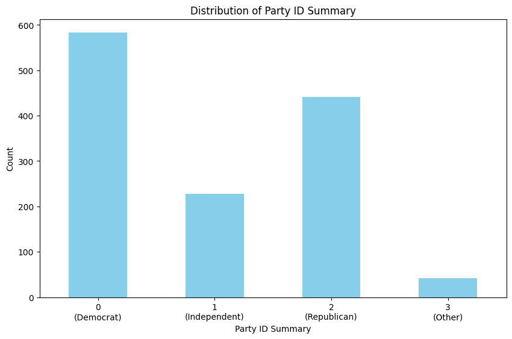

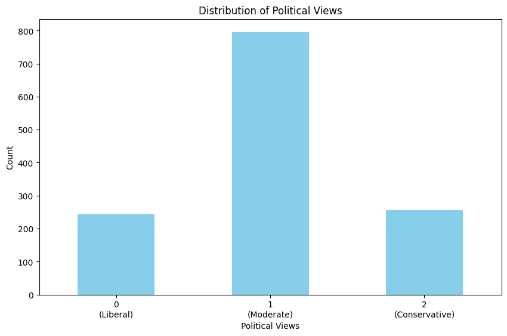

```python
import matplotlib.pyplot as plt

# Define the category names
partyid_categories = {0: 'Democrat', 1: 'Independent', 2: 'Republican', 3: 'Other'}
polviews_categories = {0: 'Liberal', 1: 'Moderate', 2: 'Conservative'}

# Plot the bar chart for partyid_summary
plt.figure(figsize=(10, 6))
partyid_counts = df_new['partyid_summary'].value_counts().sort_index()
partyid_counts.plot(kind='bar', color='skyblue')
plt.title('Distribution of Party ID Summary')
plt.xlabel('Party ID Summary')
plt.ylabel('Count')
plt.xticks(ticks=range(len(partyid_categories)), labels=[f"{k}\n({v})" for k, v in partyid_categories.items()], rotation=0)
plt.show()

# Plot the bar chart for polviews_group
plt.figure(figsize=(10, 6))
polviews_counts = df_new['polviews_group'].value_counts().sort_index()
polviews_counts.plot(kind='bar', color='skyblue')
plt.title('Distribution of Political Views')
plt.xlabel('Political Views')
plt.ylabel('Count')
plt.xticks(ticks=range(len(polviews_categories)), labels=[f"{k}\n({v})" for k, v in polviews_categories.items()], rotation=0)
plt.show()
```

### Interpretation of the bar charts

The first bar chart illustrates the distribution of party ID summaries from the GSS2022 dataset. The categories are encoded as numerical values, where '0' represents Democrats, '1' represents Independents, '2' represents Republicans, and '3' represents Other. The chart shows that the largest group, Democrats, consists of nearly 600 samples. This is followed by Republicans with about 450 samples, Independents with approximately 250 samples, and the smallest group, Other, with less than 100 samples.

The second bar chart represents the distribution of political views from the same dataset. The categories are similarly encoded as numerical values. The largest category, represented by '1', has almost 800 samples. The next two categories, represented by '2' and '0', have a roughly equal number of samples, both below 300. These charts provide a clear visual summary of the distribution of key variables within the dataset.

### Pie charts

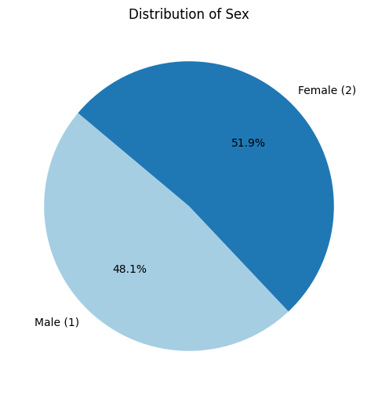

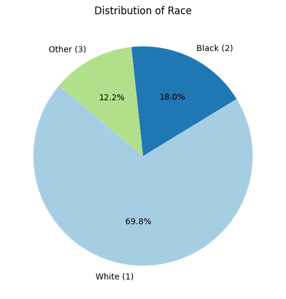

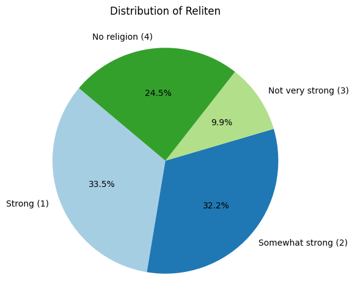

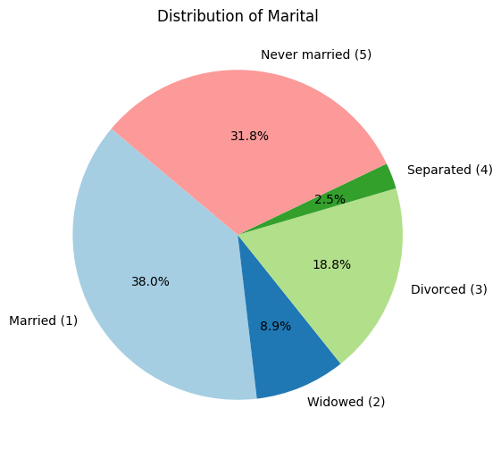

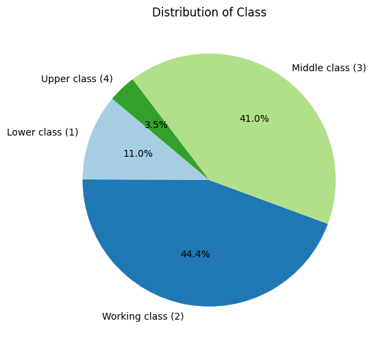

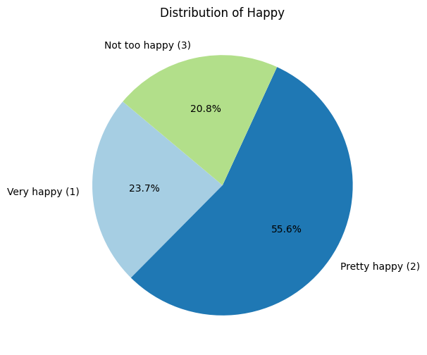

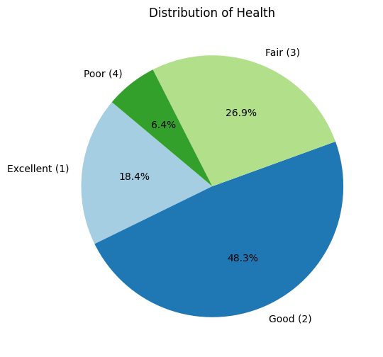

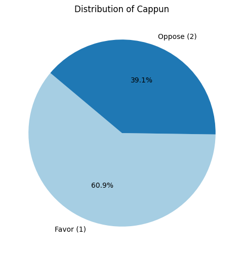

```python
import matplotlib.pyplot as plt

# Define dictionaries for categories
sex_dict = {1: 'Male', 2: 'Female'}
race_dict = {1: 'White', 2: 'Black', 3: 'Other'}
reliten_dict = {1: 'Strong', 2: 'Somewhat strong', 3: 'Not very strong', 4: 'No religion'}
marital_dict = {1: 'Married', 2: 'Widowed', 3: 'Divorced', 4: 'Separated', 5: 'Never married'}
class_dict = {1: 'Lower class', 2: 'Working class', 3: 'Middle class', 4: 'Upper class'}
happy_dict = {1: 'Very happy', 2: 'Pretty happy', 3: 'Not too happy'}
health_dict = {1: 'Excellent', 2: 'Good', 3: 'Fair', 4: 'Poor'}
cappun_dict = {1: 'Favor', 2: 'Oppose'}

# Function to create pie charts
def create_pie_chart(column, category_dict):
    plt.figure(figsize=(8, 6))
    value_counts = df_new[column].value_counts().sort_index()
    labels = [f"{category_dict.get(val, 'Unknown')} ({val})" for val in value_counts.index]
    plt.pie(value_counts, labels=labels, autopct='%1.1f%%', startangle=140, colors=plt.cm.Paired.colors)
    plt.title(f'Distribution of {column.capitalize()}')
    plt.ylabel('')
    plt.show()

# List of variables and their corresponding dictionaries
variables = {
    'sex': sex_dict,
    'race': race_dict,
    'reliten': reliten_dict,
    'marital': marital_dict,
    'class': class_dict,
    'happy': happy_dict,
    'health': health_dict,
    'cappun': cappun_dict
}

# Generate pie charts for each variable
for var, cat_dict in variables.items():
    create_pie_chart(var, cat_dict)
```

### Neural network model. Epoch=50, batch size=32.

This code sets up and trains a neural network model to predict political party affiliation based on various features. The dataset is split into training (80%) and testing (20%) sets. The model is created with multiple layers using the ReLU activation function to learn complex patterns, and the final layer uses softmax to output probabilities for each class.

The model is compiled with the sparse categorical cross-entropy loss function for multi-class classification and the Adam optimizer for efficient training. The performance is evaluated using the accuracy metric.

The model is trained for 50 epochs, meaning it passes through the entire training dataset 50 times, and uses a batch size of 32, meaning it updates its parameters after processing every 32 samples.

```
33/33 ━━━━━━━━━━━━━━━━━━━━ 3s 13ms/step - accuracy: 0.4144 - loss: 1.2177 - val_accuracy: 0.5385 - val_loss: 1.0981
33/33 ━━━━━━━━━━━━━━━━━━━━ 0s 4ms/step - accuracy: 0.5430 - loss: 1.0730 - val_accuracy: 0.5731 - val_loss: 1.0344
33/33 ━━━━━━━━━━━━━━━━━━━━ 0s 3ms/step - accuracy: 0.5932 - loss: 1.0137 - val_accuracy: 0.5731 - val_loss: 1.0025
33/33 ━━━━━━━━━━━━━━━━━━━━ 0s 3ms/step - accuracy: 0.6074 - loss: 0.9732 - val_accuracy: 0.5731 - val_loss: 0.9830
33/33 ━━━━━━━━━━━━━━━━━━━━ 0s 3ms/step - accuracy: 0.6102 - loss: 0.9446 - val_accuracy: 0.6000 - val_loss: 0.9695
33/33 ━━━━━━━━━━━━━━━━━━━━ 0s 3ms/step - accuracy: 0.6228 - loss: 0.9276 - val_accuracy: 0.6308 - val_loss: 0.9622
33/33 ━━━━━━━━━━━━━━━━━━━━ 0s 3ms/step - accuracy: 0.6197 - loss: 0.9154 - val_accuracy: 0.6192 - val_loss: 0.9567
33/33 ━━━━━━━━━━━━━━━━━━━━ 0s 3ms/step - accuracy: 0.6242 - loss: 0.9061 - val_accuracy: 0.6192 - val_loss: 0.9525
33/33 ━━━━━━━━━━━━━━━━━━━━ 0s 3ms/step - accuracy: 0.6290 - loss: 0.8982 - val_accuracy: 0.6154 - val_loss: 0.9511
33/33 ━━━━━━━━━━━━━━━━━━━━ 0s 3ms/step - accuracy: 0.6313 - loss: 0.8908 - val_accuracy: 0.6231 - val_loss: 0.9503
33/33 ━━━━━━━━━━━━━━━━━━━━ 0s 3ms/step - accuracy: 0.6341 - loss: 0.8845 - val_accuracy: 0.6154 - val_loss: 0.9509
33/33 ━━━━━━━━━━━━━━━━━━━━ 0s 3ms/step - accuracy: 0.6357 - loss: 0.8790 - val_accuracy: 0.6192 - val_loss: 0.9510
33/33 ━━━━━━━━━━━━━━━━━━━━ 0s 3ms/step - accuracy: 0.6406 - loss: 0.8732 - val_accuracy: 0.6154 - val_loss: 0.9517
33/33 ━━━━━━━━━━━━━━━━━━━━ 0s 3ms/step - accuracy: 0.6387 - loss: 0.8672 - val_accuracy: 0.6231 - val_loss: 0.9531
33/33 ━━━━━━━━━━━━━━━━━━━━ 0s 3ms/step - accuracy: 0.6472 - loss: 0.8609 - val_accuracy: 0.6231 - val_loss: 0.9525
33/33 ━━━━━━━━━━━━━━━━━━━━ 0s 4ms/step - accuracy: 0.6473 - loss: 0.8557 - val_accuracy: 0.6192 - val_loss: 0.9548
33/33 ━━━━━━━━━━━━━━━━━━━━ 0s 3ms/step - accuracy: 0.6510 - loss: 0.8482 - val_accuracy: 0.6154 - val_loss: 0.9556
33/33 ━━━━━━━━━━━━━━━━━━━━ 0s 3ms/step - accuracy: 0.6531 - loss: 0.8413 - val_accuracy: 0.6154 - val_loss: 0.9544
33/33 ━━━━━━━━━━━━━━━━━━━━ 0s 3ms/step - accuracy: 0.6597 - loss: 0.8366 - val_accuracy: 0.6077 - val_loss: 0.9574
33/33 ━━━━━━━━━━━━━━━━━━━━ 0s 3ms/step - accuracy: 0.6522 - loss: 0.8291 - val_accuracy: 0.6115 - val_loss: 0.9569
33/33 ━━━━━━━━━━━━━━━━━━━━ 0s 3ms/step - accuracy: 0.6616 - loss: 0.8236 - val_accuracy: 0.6115 - val_loss: 0.9595
33/33 ━━━━━━━━━━━━━━━━━━━━ 0s 3ms/step - accuracy: 0.6672 - loss: 0.8160 - val_accuracy: 0.6077 - val_loss: 0.9593
33/33 ━━━━━━━━━━━━━━━━━━━━ 0s 3ms/step - accuracy: 0.6657 - loss: 0.8095 - val_accuracy: 0.6115 - val_loss: 0.9617
33/33 ━━━━━━━━━━━━━━━━━━━━ 0s 3ms/step - accuracy: 0.6756 - loss: 0.8027 - val_accuracy: 0.6115 - val_loss: 0.9626
33/33 ━━━━━━━━━━━━━━━━━━━━ 0s 3ms/step - accuracy: 0.6784 - loss: 0.7963 - val_accuracy: 0.6231 - val_loss: 0.9623
33/33 ━━━━━━━━━━━━━━━━━━━━ 0s 3ms/step - accuracy: 0.6866 - loss: 0.7892 - val_accuracy: 0.6115 - val_loss: 0.9626
33/33 ━━━━━━━━━━━━━━━━━━━━ 0s 3ms/step - accuracy: 0.6877 - loss: 0.7815 - val_accuracy: 0.6115 - val_loss: 0.9625
33/33 ━━━━━━━━━━━━━━━━━━━━ 0s 4ms/step - accuracy: 0.6883 - loss: 0.7743 - val_accuracy: 0.6115 - val_loss: 0.9593
33/33 ━━━━━━━━━━━━━━━━━━━━ 0s 4ms/step - accuracy: 0.6893 - loss: 0.7683 - val_accuracy: 0.6154 - val_loss: 0.9625
33/33 ━━━━━━━━━━━━━━━━━━━━ 0s 3ms/step - accuracy: 0.6944 - loss: 0.7617 - val_accuracy: 0.6077 - val_loss: 0.9655
33/33 ━━━━━━━━━━━━━━━━━━━━ 0s 3ms/step - accuracy: 0.6983 - loss: 0.7541 - val_accuracy: 0.6154 - val_loss: 0.9670
33/33 ━━━━━━━━━━━━━━━━━━━━ 0s 4ms/step - accuracy: 0.6976 - loss: 0.7485 - val_accuracy: 0.6115 - val_loss: 0.9729
33/33 ━━━━━━━━━━━━━━━━━━━━ 0s 5ms/step - accuracy: 0.7101 - loss: 0.7426 - val_accuracy: 0.6077 - val_loss: 0.9763
33/33 ━━━━━━━━━━━━━━━━━━━━ 0s 4ms/step - accuracy: 0.7043 - loss: 0.7366 - val_accuracy: 0.6077 - val_loss: 0.9834
33/33 ━━━━━━━━━━━━━━━━━━━━ 0s 4ms/step - accuracy: 0.7096 - loss: 0.7288 - val_accuracy: 0.6077 - val_loss: 0.9836
33/33 ━━━━━━━━━━━━━━━━━━━━ 0s 4ms/step - accuracy: 0.7193 - loss: 0.7226 - val_accuracy: 0.6077 - val_loss: 0.9885
33/33 ━━━━━━━━━━━━━━━━━━━━ 0s 3ms/step - accuracy: 0.7229 - loss: 0.7152 - val_accuracy: 0.6115 - val_loss: 0.9866
33/33 ━━━━━━━━━━━━━━━━━━━━ 0s 4ms/step - accuracy: 0.7153 - loss: 0.7118 - val_accuracy: 0.6038 - val_loss: 0.9962
33/33 ━━━━━━━━━━━━━━━━━━━━ 0s 3ms/step - accuracy: 0.7241 - loss: 0.7043 - val_accuracy: 0.6038 - val_loss: 1.0008
33/33 ━━━━━━━━━━━━━━━━━━━━ 0s 4ms/step - accuracy: 0.7222 - loss: 0.7012 - val_accuracy: 0.5962 - val_loss: 1.0095
```

[output cut: 15 more lines]

```

    Democrat       0.57      0.71      0.63       108
 Independent       0.33      0.31      0.32        51
  Republican       0.72      0.59      0.65        94
       Other       0.00      0.00      0.00         7

    accuracy                           0.57       260
   macro avg       0.41      0.40      0.40       260
weighted avg       0.56      0.57      0.56       260

Confusion Matrix for Neural Network:
[[77 20 11  0]
 [28 16  7  0]
 [26 13 55  0]
 [ 4  0  3  0]]
```

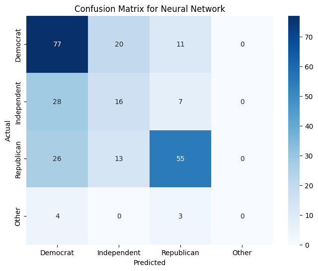

```python
import numpy as np
import pandas as pd
import matplotlib.pyplot as plt
import seaborn as sns
from sklearn.model_selection import train_test_split
from tensorflow.keras.models import Sequential
from tensorflow.keras.layers import Dense
from sklearn.metrics import classification_report, confusion_matrix
import tensorflow as tf
import random

# Set random seeds for reproducibility
np.random.seed(42)
tf.random.set_seed(42)
random.seed(42)

# Ensure all data is in the correct format
df_new = df_new.apply(pd.to_numeric, errors='coerce')

# Define the target variable and features
target = 'partyid_summary'
X = df_new.drop(columns=[target])
y = df_new[target]

# Split the data into training and testing sets
X_train, X_test, y_train, y_test = train_test_split(X, y, test_size=0.2, random_state=42)

# Create the neural network model
model = Sequential()
model.add(Dense(64, activation='relu', input_shape=(X_train.shape[1],)))
model.add(Dense(32, activation='relu'))
model.add(Dense(16, activation='relu'))
model.add(Dense(len(np.unique(y)), activation='softmax'))

# Compile the model
model.compile(loss='sparse_categorical_crossentropy', optimizer='adam', metrics=['accuracy'])

# Train the model
model.fit(X_train, y_train, epochs=50, batch_size=32, validation_data=(X_test, y_test))

# Evaluate the model
loss, accuracy = model.evaluate(X_test, y_test)
print(f"Accuracy of the Neural Network model: {accuracy:.2f}")

# Generate predictions and classification report
y_pred = model.predict(X_test)
y_pred_classes = np.argmax(y_pred, axis=1)

print("Classification Report for Neural Network:")
print(classification_report(y_test, y_pred_classes, target_names=['Democrat', 'Independent', 'Republican', 'Other']))

# Generate the confusion matrix
conf_matrix = confusion_matrix(y_test, y_pred_classes)
print("Confusion Matrix for Neural Network:")
print(conf_matrix)

# Plot the confusion matrix
plt.figure(figsize=(8, 6))
sns.heatmap(conf_matrix, annot=True, fmt='d', cmap='Blues', xticklabels=['Democrat', 'Independent', 'Republican', 'Other'], yticklabels=['Democrat', 'Independent', 'Republican', 'Other'])
plt.title('Confusion Matrix for Neural Network')
plt.xlabel('Predicted')
plt.ylabel('Actual')
plt.show()
```

### Results of the model

The neural network model was trained over 50 epochs, and the results indicate the learning process at each epoch. An epoch is one complete pass through the entire training dataset. The batch size is 32, meaning the model updates its weights after processing every 32 samples.

Initially, the model's accuracy starts at 41.4%, with a training loss of 1.2177 and a validation accuracy of 53.8%. As training progresses, the accuracy and loss values fluctuate, reflecting the model's adjustments to better fit the data. By the end of the 50th epoch, the training accuracy reaches 74.8%, and the validation accuracy is 57.0%, indicating that the model has learned from the data but still has room for improvement.

The neural network model achieved an overall accuracy of 57% in predicting political party affiliation. It performs reasonably well for Democrats, correctly identifying 71% of cases with a precision of 57% and an F1-score of 63%. For Independents, the model has moderate success, with 31% recall, 33% precision, and an F1-score of 32%. Republicans show higher precision at 72% but a lower recall of 59%, resulting in an F1-score of 65%. The model struggles significantly with the 'Other' category, failing to correctly identify any instances.

The confusion matrix reveals that out of 108 actual Democrats, 77 were correctly predicted, while the rest were misclassified as Independents or Republicans. Similar patterns of misclassification are seen in other categories. Overall, the model shows good performance for Democrats and Republicans but needs improvement in predicting Independents and the 'Other' category.

### Neural Network Model. Epochs=100, Batch_size=64, learning_rate=0.0001

This code sets up and trains a neural network model to predict political party affiliation, similar to the previous model but with several enhancements aimed at improving accuracy. The dataset is split into training (80%) and testing (20%) sets, ensuring the model is trained on a substantial portion of the data while reserving a separate set for evaluating its performance.

The new model architecture has been modified to include more layers and neurons, making it more complex and capable of learning intricate patterns in the data. The first layer consists of 128 neurons with ReLU activation, followed by a second layer with 64 neurons and a third layer with 32 neurons, both also using ReLU activation. The final layer uses softmax activation to output probabilities for each class, allowing the model to predict the political party affiliation based on the input features.

To prevent overfitting and improve generalization, dropout layers are added after the first two dense layers with a dropout rate of 0.3. Dropout randomly sets a fraction of input units to zero during training, which helps the model become more robust by not relying too heavily on any single neuron.

The model uses the Adam optimizer with a specified learning rate of 0.0001, providing finer control over the learning process. This adjustment aims to ensure that the model converges more effectively during training. Additionally, early stopping is implemented to monitor the validation loss, stopping the training if the model doesn't improve for five consecutive epochs and restoring the best weights from the training process. This mechanism helps in preventing overfitting and ensures the model maintains its best performance on the validation set.

Compared to the previous neural network model, these enhancements—additional layers, dropout regularization, a specified learning rate for the optimizer, and early stopping—are introduced to improve the model's accuracy and robustness. The increased complexity and regularization techniques aim to better capture the underlying patterns in the data, ultimately leading to more accurate predictions of political party affiliation.

```
17/17 ━━━━━━━━━━━━━━━━━━━━ 2s 20ms/step - accuracy: 0.3453 - loss: 1.4922 - val_accuracy: 0.4154 - val_loss: 1.3288
17/17 ━━━━━━━━━━━━━━━━━━━━ 0s 5ms/step - accuracy: 0.4136 - loss: 1.3831 - val_accuracy: 0.4154 - val_loss: 1.2644
17/17 ━━━━━━━━━━━━━━━━━━━━ 0s 5ms/step - accuracy: 0.4437 - loss: 1.2875 - val_accuracy: 0.4154 - val_loss: 1.2207
17/17 ━━━━━━━━━━━━━━━━━━━━ 0s 5ms/step - accuracy: 0.4093 - loss: 1.2918 - val_accuracy: 0.4154 - val_loss: 1.1920
17/17 ━━━━━━━━━━━━━━━━━━━━ 0s 5ms/step - accuracy: 0.4474 - loss: 1.2338 - val_accuracy: 0.4154 - val_loss: 1.1728
17/17 ━━━━━━━━━━━━━━━━━━━━ 0s 6ms/step - accuracy: 0.4488 - loss: 1.2199 - val_accuracy: 0.4077 - val_loss: 1.1588
17/17 ━━━━━━━━━━━━━━━━━━━━ 0s 5ms/step - accuracy: 0.4303 - loss: 1.1985 - val_accuracy: 0.4077 - val_loss: 1.1488
17/17 ━━━━━━━━━━━━━━━━━━━━ 0s 5ms/step - accuracy: 0.4379 - loss: 1.1966 - val_accuracy: 0.4192 - val_loss: 1.1398
17/17 ━━━━━━━━━━━━━━━━━━━━ 0s 5ms/step - accuracy: 0.4304 - loss: 1.1737 - val_accuracy: 0.4308 - val_loss: 1.1324
17/17 ━━━━━━━━━━━━━━━━━━━━ 0s 7ms/step - accuracy: 0.4596 - loss: 1.1718 - val_accuracy: 0.4385 - val_loss: 1.1268
17/17 ━━━━━━━━━━━━━━━━━━━━ 0s 5ms/step - accuracy: 0.4319 - loss: 1.1900 - val_accuracy: 0.4462 - val_loss: 1.1210
17/17 ━━━━━━━━━━━━━━━━━━━━ 0s 6ms/step - accuracy: 0.4461 - loss: 1.1670 - val_accuracy: 0.4462 - val_loss: 1.1168
17/17 ━━━━━━━━━━━━━━━━━━━━ 0s 5ms/step - accuracy: 0.4428 - loss: 1.1584 - val_accuracy: 0.4500 - val_loss: 1.1114
17/17 ━━━━━━━━━━━━━━━━━━━━ 0s 5ms/step - accuracy: 0.4211 - loss: 1.1598 - val_accuracy: 0.4692 - val_loss: 1.1061
17/17 ━━━━━━━━━━━━━━━━━━━━ 0s 6ms/step - accuracy: 0.4728 - loss: 1.1444 - val_accuracy: 0.4731 - val_loss: 1.1017
17/17 ━━━━━━━━━━━━━━━━━━━━ 0s 7ms/step - accuracy: 0.4679 - loss: 1.1422 - val_accuracy: 0.4731 - val_loss: 1.0984
17/17 ━━━━━━━━━━━━━━━━━━━━ 0s 5ms/step - accuracy: 0.4736 - loss: 1.1538 - val_accuracy: 0.4769 - val_loss: 1.0953
17/17 ━━━━━━━━━━━━━━━━━━━━ 0s 6ms/step - accuracy: 0.4864 - loss: 1.1423 - val_accuracy: 0.4923 - val_loss: 1.0918
17/17 ━━━━━━━━━━━━━━━━━━━━ 0s 5ms/step - accuracy: 0.4958 - loss: 1.1204 - val_accuracy: 0.4923 - val_loss: 1.0888
17/17 ━━━━━━━━━━━━━━━━━━━━ 0s 5ms/step - accuracy: 0.4752 - loss: 1.1134 - val_accuracy: 0.4962 - val_loss: 1.0859
17/17 ━━━━━━━━━━━━━━━━━━━━ 0s 6ms/step - accuracy: 0.4620 - loss: 1.1286 - val_accuracy: 0.5000 - val_loss: 1.0823
17/17 ━━━━━━━━━━━━━━━━━━━━ 0s 5ms/step - accuracy: 0.4785 - loss: 1.1229 - val_accuracy: 0.5038 - val_loss: 1.0794
17/17 ━━━━━━━━━━━━━━━━━━━━ 0s 5ms/step - accuracy: 0.4770 - loss: 1.1169 - val_accuracy: 0.5115 - val_loss: 1.0763
17/17 ━━━━━━━━━━━━━━━━━━━━ 0s 5ms/step - accuracy: 0.4618 - loss: 1.1164 - val_accuracy: 0.5115 - val_loss: 1.0729
17/17 ━━━━━━━━━━━━━━━━━━━━ 0s 5ms/step - accuracy: 0.5060 - loss: 1.1160 - val_accuracy: 0.5115 - val_loss: 1.0712
17/17 ━━━━━━━━━━━━━━━━━━━━ 0s 5ms/step - accuracy: 0.5001 - loss: 1.1111 - val_accuracy: 0.5192 - val_loss: 1.0675
17/17 ━━━━━━━━━━━━━━━━━━━━ 0s 5ms/step - accuracy: 0.5031 - loss: 1.1058 - val_accuracy: 0.5192 - val_loss: 1.0651
17/17 ━━━━━━━━━━━━━━━━━━━━ 0s 5ms/step - accuracy: 0.4964 - loss: 1.1212 - val_accuracy: 0.5231 - val_loss: 1.0622
17/17 ━━━━━━━━━━━━━━━━━━━━ 0s 5ms/step - accuracy: 0.4899 - loss: 1.1115 - val_accuracy: 0.5269 - val_loss: 1.0598
17/17 ━━━━━━━━━━━━━━━━━━━━ 0s 5ms/step - accuracy: 0.4965 - loss: 1.1122 - val_accuracy: 0.5346 - val_loss: 1.0561
17/17 ━━━━━━━━━━━━━━━━━━━━ 0s 5ms/step - accuracy: 0.5227 - loss: 1.0719 - val_accuracy: 0.5423 - val_loss: 1.0519
17/17 ━━━━━━━━━━━━━━━━━━━━ 0s 6ms/step - accuracy: 0.5156 - loss: 1.0898 - val_accuracy: 0.5538 - val_loss: 1.0479
17/17 ━━━━━━━━━━━━━━━━━━━━ 0s 6ms/step - accuracy: 0.5171 - loss: 1.0970 - val_accuracy: 0.5615 - val_loss: 1.0436
17/17 ━━━━━━━━━━━━━━━━━━━━ 0s 6ms/step - accuracy: 0.5124 - loss: 1.1065 - val_accuracy: 0.5692 - val_loss: 1.0392
17/17 ━━━━━━━━━━━━━━━━━━━━ 0s 6ms/step - accuracy: 0.5435 - loss: 1.0774 - val_accuracy: 0.5654 - val_loss: 1.0368
17/17 ━━━━━━━━━━━━━━━━━━━━ 0s 6ms/step - accuracy: 0.5369 - loss: 1.0643 - val_accuracy: 0.5654 - val_loss: 1.0336
17/17 ━━━━━━━━━━━━━━━━━━━━ 0s 6ms/step - accuracy: 0.4873 - loss: 1.0832 - val_accuracy: 0.5769 - val_loss: 1.0298
17/17 ━━━━━━━━━━━━━━━━━━━━ 0s 6ms/step - accuracy: 0.5051 - loss: 1.0724 - val_accuracy: 0.5808 - val_loss: 1.0259
17/17 ━━━━━━━━━━━━━━━━━━━━ 0s 6ms/step - accuracy: 0.5005 - loss: 1.0801 - val_accuracy: 0.5769 - val_loss: 1.0229
17/17 ━━━━━━━━━━━━━━━━━━━━ 0s 6ms/step - accuracy: 0.5526 - loss: 1.0695 - val_accuracy: 0.5846 - val_loss: 1.0193
```

[output cut: 65 more lines]

```

    Democrat       0.61      0.81      0.70       108
 Independent       0.58      0.29      0.39        51
  Republican       0.72      0.68      0.70        94
       Other       0.00      0.00      0.00         7

    accuracy                           0.64       260
   macro avg       0.48      0.45      0.45       260
weighted avg       0.63      0.64      0.62       260

Confusion Matrix for Neural Network:
[[88  8 12  0]
 [27 15  9  0]
 [27  3 64  0]
 [ 3  0  4  0]]
```

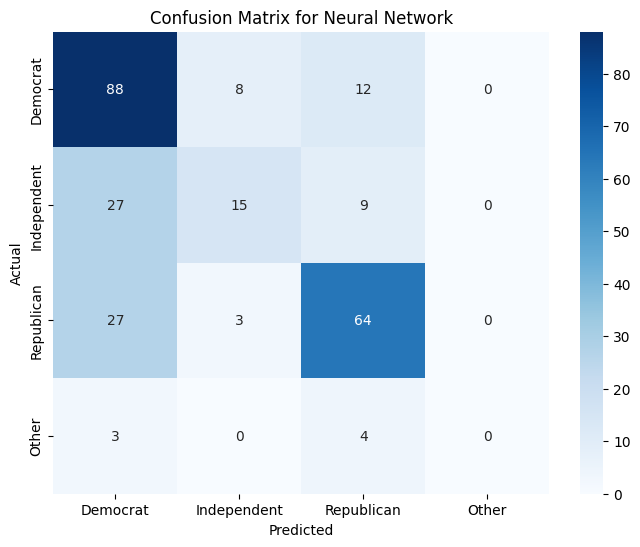

```python
import numpy as np
import pandas as pd
from sklearn.model_selection import train_test_split
from tensorflow.keras.models import Sequential
from tensorflow.keras.layers import Dense, Dropout
from tensorflow.keras.callbacks import EarlyStopping
from tensorflow.keras.optimizers import Adam
from sklearn.metrics import classification_report, confusion_matrix
import tensorflow as tf
import random

# Set random seeds for reproducibility
np.random.seed(42)
tf.random.set_seed(42)
random.seed(42)

# Define the target variable and features
target = 'partyid_summary'
X = df_new.drop(columns=[target])
y = df_new[target]

# Split the data into training and testing sets
X_train, X_test, y_train, y_test = train_test_split(X, y, test_size=0.2, random_state=42)

# Create the neural network model with different dropout rates and batch size
model = Sequential()
model.add(Dense(128, activation='relu', input_shape=(X_train.shape[1],)))
model.add(Dropout(0.3))
model.add(Dense(64, activation='relu'))
model.add(Dropout(0.3))
model.add(Dense(32, activation='relu'))
model.add(Dense(len(np.unique(y)), activation='softmax'))

# Compile the model with the Adam optimizer and a specified learning rate
adam_optimizer = Adam(learning_rate=0.0001)
model.compile(loss='sparse_categorical_crossentropy', optimizer=adam_optimizer, metrics=['accuracy'])

# Early stopping
early_stopping = EarlyStopping(monitor='val_loss', patience=5, restore_best_weights=True)

# Train the model
model.fit(X_train, y_train, epochs=100, batch_size=64, validation_data=(X_test, y_test), callbacks=[early_stopping])

# Evaluate the model
loss, accuracy = model.evaluate(X_test, y_test)
print(f"Accuracy of the Neural Network model: {accuracy:.2f}")

# Generate predictions and classification report
y_pred = model.predict(X_test)
y_pred_classes = np.argmax(y_pred, axis=1)

print("Classification Report for Neural Network:")
print(classification_report(y_test, y_pred_classes, target_names=['Democrat', 'Independent', 'Republican', 'Other']))

# Generate the confusion matrix
conf_matrix = confusion_matrix(y_test, y_pred_classes)
print("Confusion Matrix for Neural Network:")
print(conf_matrix)

# Plot the confusion matrix
plt.figure(figsize=(8, 6))
sns.heatmap(conf_matrix, annot=True, fmt='d', cmap='Blues', xticklabels=['Democrat', 'Independent', 'Republican', 'Other'], yticklabels=['Democrat', 'Independent', 'Republican', 'Other'])
plt.title('Confusion Matrix for Neural Network')
plt.xlabel('Predicted')
plt.ylabel('Actual')
plt.show()
```

### Results of the model

Initially, the model's accuracy starts at 34.5%, with a training loss of 1.4922 and a validation accuracy of 41.5%. As training progresses, the accuracy and loss values fluctuate, reflecting the model's adjustments to better fit the data. By the end of the 100th epoch, the training accuracy reaches 57.4%, and the validation accuracy is 64.6%, indicating that the model has learned from the data and has shown improvement.

The neural network model achieved an overall accuracy of 64% in predicting political party affiliation, which is higher than the previous model's accuracy of 57%. For Democrats, the model correctly identifies 81% of cases with a precision of 61% and an F1-score of 70%, compared to the previous model's 71% recall, 57% precision, and 63% F1-score. This shows a significant improvement in recall and overall performance.

Republicans have a precision of 72% and a recall of 68%, resulting in an F1-score of 70%, which is an improvement compared to the previous model's 72% precision, 59% recall, and 65% F1-score. The model still fails to predict the 'Other' category accurately, similar to the previous model.

The confusion matrix reveals that out of 108 actual Democrats, 88 were correctly predicted, while misclassifications occurred among Independents and Republicans. Similar patterns of misclassification are seen in other categories. Overall, the model shows better performance for Democrats and Republicans and has improved for Independents but still needs significant improvement for the 'Other' category.

# Conclusion

This project aimed to predict political party affiliation based on socio-demographic factors using datasets from the General Social Survey (GSS). By leveraging the GSSIdeology and GSS_2022 datasets, the project sought to build models that accurately categorize individuals into political parties based on characteristics such as age, sex, marital status, ideology, religion, income, and social class.

The AdaBoost model achieved an accuracy of 54%, slightly lower than the random forest model. The performance metrics for Democrats and Republicans remained similar, with slight improvements in predicting Republicans. However, the model continued to struggle with Independents and the Missing category, demonstrating that boosting did not substantially enhance the classification accuracy for this dataset.

To further explore the prediction accuracy, neural network models were trained using the GSS_2022 dataset. The first neural network model, trained over 50 epochs, achieved an accuracy of 57%. It showed decent performance for Democrats and Republicans but continued to struggle with Independents and the 'Other' category.

In an attempt to enhance the model's performance, a more complex neural network with different dropout rates and batch sizes was trained over 100 epochs. This model achieved an accuracy of 64%, showing a marked improvement over the previous neural network. It performed significantly better for Democrats and Republicans, with F1-scores of 70% for both categories. The model also showed improved performance for Independents, with an F1-score of 39%. However, it still failed to accurately predict the 'Other' category.

Overall, the neural network trained over 100 epochs on the GSS_2022 dataset demonstrated the best performance among the models tested, indicating that a deeper and more complex model could better capture the nuances in the data. While the improved model shows promise, further refinement is necessary, particularly in addressing the challenges of predicting less common categories such as Independents and 'Other'.

# References

Tanuzi, B. & Franklin, J. (2022). How Do Socio-demographic Factors Determine the Political Party Affiliation of Americans? Do Race and Region Affect Differently for Similar Political Views Levels? SSRN. http://dx.doi.org/10.2139/ssrn.4693183

GSS2022.(2022). GSS. Retrieved August, 1st, 2024 from https://gss.norc.org/get-the-data/stata

GSSIdeology. (n.d.). Retrieved (n.d) from https://gss.norc.org/get-the-data/stata